# Study 1: Replicating Wegner & Erber (1992)

Kai Qin Chan with notes+reproducibility additions by Ian Hussey

Lead authors: Deming (Adam) Wang, Kai Qin Chan, Wakefield Morys-Carter, and Martin Hagger

- Version 1: Based on R codes previously approved by AAMPS editor in Oct 2022
- Version 2: Dec 2023.
- Version 3: June 2025.
- Version 4: Aug 2025.

System ran 13th Gen Intel(R) Core(TM) i7-1355U 1.70 GHz 16.0 GB (15.7 GB usable)

General Warning RStudio may crash when looping over mixed models. If so, restart RStudio to free up RAM.

Resources consulted

- https://r-workshop.mindsci.net/anova — for effect size
- https://stackoverflow.com/questions/68955079/how-to-print-and-skip-error-in-for-loop-in-r-with-hsd-analysis — for skip errors
- https://jonlefcheck.net/2013/05/20/continuing-a-for-loop-in-r-after-an-error/ — for skip errors
- https://irrsim.bryer.org/articles/IRRsim.html

# Dependencies

```r
####Load libraries####
library(readxl); library(psych); library(reshape2); library(afex); library(emmeans); library(irr); library(dplyr); library(metafor); library(forestplot); library(stringr)
library(janitor); library(tidyr); library(knitr); library(kableExtra)

####Set global options
options(scipen=999) #Disables expressing small numbers in scientific notation, e. Otherwise it creates problematic Excel files.
options(digits = 4)
```

# Load data

```r
####Create list of Excel datafiles and temp dataframes within working directory####
file_list <- list.files(path = "../../data/processed/study 1/",
                        pattern="*.xlsx") #get all data with .xlsx (must define working directory first)
file_list <- paste0("../../data/processed/study 1/", file_list)

data_list <- vector("list", length = length(file_list)) # This empty list will store the dataframes read from each file
loop_times <- numeric(100) #capture loop time

df1 <- data.frame(Lab = NA_character_, Researcher = NA_character_, Country = NA_character_, Citation = NA_character_,
                  N.initial = NA_real_, N.final = NA_real_, N.male = NA_real_, N.female = NA_real_, N.other = NA_real_, pct.N.incl = NA_real_,
                  N.conc = NA_real_, N.supp = NA_real_,

                  IRR = NA_real_,

                  min.age = NA_real_, max.age = NA_real_, mean.age = NA_real_, sd.age = NA_real_,

                  count.Manipchk.fail = NA_real_, count.Manipchk.pass = NA_real_, pct.Manipchk.pass = NA_real_,
                  count.Compliance.fail = NA_real_, count.Compliance.pass = NA_real_, pct.Compliance.pass = NA_real_,
                  count.Probe.fail = NA_real_, count.Probe.pass = NA_real_, pct.Probe.pass = NA_real_,

                  mean.conc.3s = NA_real_, mean.supp.3s = NA_real_,
                  mean.conc.10s = NA_real_, mean.supp.10s = NA_real_,
                  sd.conc.3s = NA_real_, sd.supp.3s = NA_real_,
                  sd.conc.10s = NA_real_, sd.supp.10s = NA_real_,

                  ES.cond_TP_wordtype_replication = NA_real_,
                  ES.allwords.cond_TP_wordtype = NA_real_, ES.allwords.cond_wordtype = NA_real_, ES.allwords.cond_TP = NA_real_,
                  ES.targetwords.cond = NA_real_, ES.targetwords.TP = NA_real_, ES.targetwords.cond_TP= NA_real_,
                  ES.nontargetwords.cond = NA_real_, ES.nontargetwords.TP = NA_real_,

                  FE.GLMM.allwordtype.Cond = NA_real_, FE.GLMM.allwordtype.TP = NA_real_, FE.GLMM.allwordtype.Wordtype = NA_real_,
                  FE.GLMM.allwordtype.Cond_TP = NA_real_, FE.GLMM.allwordtype.Cond_Wordtype = NA_real_, FE.GLMM.allwordtype.TP_Wordtype = NA_real_, FE.GLMM.allwordtype.cond_TP_Wordtype = NA_real_,
                  FE.GLMM.targetword.Cond = NA_real_, FE.GLMM.targetword.TP = NA_real_, FE.GLMM.targetword.Cond_TP= NA_real_,

                  VPC.m2 = NA_real_, VPC.m3 = NA_real_,

                  d.low = NA_real_, d.high = NA_real_,
                  v.low = NA_real_, v.high = NA_real_
)

####LOOP: START####
for (i in 1:36) { #Although it is more elegant to use seq_along(), using 1:n is better for debugging. Max n = 36.
  #if (i == 9) next #Use if  the 9th lab would be excluded because it has too few participants (n = 40)
  start_time <- Sys.time()
  filename = file_list[[i]]
  message("Processing file ", i, " of ", length(file_list), ": ", file_list[i]) #Progress tracker

  RRR_WE92 <- read_excel(filename, sheet = "testdata", na = "NA")

  # Rename columns for consistency
  colnames(RRR_WE92) <- recode(colnames(RRR_WE92),
                               "Participant ID" = "SubjID",
                               "Time pressure order" = "TimePressureOrder",
                               "Target word" = "Replication",
                               "Condition" = "Cond"
  )

  # Define categorical variables
  RRR_WE92 <- RRR_WE92 %>%
    mutate(
      gender = factor(gender, levels = 1:4, labels = c("Female", "Male", "Other", "Prefer not to say")),
      MC = factor(MC, levels = 1:2, labels = c("Think", "Not think")),
      Cond = factor(Cond, levels = 1:2, labels = c("Suppression", "Concentration")),
      Replication = factor(Replication),
      TimePressureOrder = factor(TimePressureOrder),
      probe.final = factor(probe.final, levels = 0:1, labels = c("pass", "fail")), #Probe: did participant fail probe? 1 = yes, 0 = no
      Compliance = factor(Compliance, levels = 1:2, labels = c("pass", "fail")) #Compliance: complied with experimental instructions? Yes = 1, No = 2
    )

  #Define levels of the categorical variables. I could define it in the above step, but it doesn't work.
  levels(RRR_WE92$Replication) <- c("mountain", "car", "child", "house")
  levels(RRR_WE92$TimePressureOrder) <- c("10s then 3s", "2s then 10s")

  ####INTER-RATER RELIABILITY, MANIPULATION CHECKS, COMPLIANCE, & SUSPICION PROBES####

  # Manipulation check: Define pass/fail conditions
  RRR_WE92 <- RRR_WE92 %>%
    mutate(Manipchk.pass = case_when(
      MC == "Think" & Cond == "Concentration" ~ "pass",
      MC == "Not think" & Cond == "Suppression" ~ "pass",
      MC == "Think" & Cond == "Suppression" ~ "fail",
      MC == "Not think" & Cond == "Concentration" ~ "fail"
    ))

  RRR_WE92$Manipchk.pass <- as.factor(RRR_WE92$Manipchk.pass) #1 = fail; 2 = pass ##NEW CODE##

  # Compute Cohen's Kappa for interrater reliability (correct responses only)
  kappa.target.low1 <- kappa2(RRR_WE92[, c("target.low1.coder1", "target.low1.coder2")], weight = "unweighted")
  kappa.target.low2 <- kappa2(RRR_WE92[, c("target.low2.coder1", "target.low2.coder2")], weight = "unweighted")
  kappa.target.high1 <- kappa2(RRR_WE92[, c("target.high1.coder1", "target.high1.coder2")], weight = "unweighted")
  kappa.target.high2 <- kappa2(RRR_WE92[, c("target.high2.coder1", "target.high2.coder2")], weight = "unweighted")
  kappa.nontarget.low1 <- kappa2(RRR_WE92[, c("nontarget.low1.coder1", "nontarget.low1.coder2")], weight = "unweighted")
  kappa.nontarget.low2 <- kappa2(RRR_WE92[, c("nontarget.low2.coder1", "nontarget.low2.coder2")], weight = "unweighted")
  kappa.nontarget.high1 <- kappa2(RRR_WE92[, c("nontarget.high1.coder1", "nontarget.high1.coder2")], weight = "unweighted")
  kappa.nontarget.high2 <- kappa2(RRR_WE92[, c("nontarget.high2.coder1", "nontarget.high2.coder2")], weight = "unweighted")

  #Compute mean Cohen's kappa for the DVs
  meankappa <- mean(c
                    (kappa.target.low1[["value"]],
                      kappa.target.low2[["value"]],
                      kappa.target.high1[["value"]],
                      kappa.target.high2[["value"]],
                      kappa.nontarget.low1[["value"]],
                      kappa.nontarget.low2[["value"]],
                      kappa.nontarget.high1[["value"]],
                      kappa.nontarget.high2[["value"]]), na.rm = TRUE)
```

```r
  #Fill in the manipulation checks, compliance, and probe numbers first, before subsetting based on preregistered exclusion criteria
  df1$N.initial = nrow(RRR_WE92)
  df1$count.Manipchk.pass <- sum(RRR_WE92$Manipchk.pass == "pass", na.rm = TRUE)
  df1$count.Manipchk.fail <- sum(RRR_WE92$Manipchk.pass == "fail", na.rm = TRUE)
  df1$pct.Manipchk.pass <- sum(RRR_WE92$Manipchk.pass == "pass", na.rm = TRUE)/(sum(RRR_WE92$Manipchk.pass == "pass", na.rm = TRUE)+sum(RRR_WE92$Manipchk.pass == "fail", na.rm = TRUE))*100

  df1$count.Compliance.pass <- sum(RRR_WE92$Compliance=="pass", na.rm = TRUE)
  df1$count.Compliance.fail <- sum(RRR_WE92$Compliance=="fail", na.rm = TRUE)
  df1$pct.Compliance.pass <- sum(RRR_WE92$Compliance=="pass", na.rm = TRUE)/(sum(RRR_WE92$Compliance=="pass", na.rm = TRUE)+sum(RRR_WE92$Compliance=="fail", na.rm = TRUE))*100

  df1$count.Probe.pass <- sum(RRR_WE92$probe.final=="pass", na.rm = TRUE)
  df1$count.Probe.fail <- sum(RRR_WE92$probe.final=="fail", na.rm = TRUE)
  df1$pct.Probe.pass <-sum(RRR_WE92$probe.final=="pass", na.rm = TRUE)/(sum(RRR_WE92$probe.final=="pass", na.rm = TRUE)+sum(RRR_WE92$probe.final=="fail", na.rm = TRUE))*100

  ####Toggle between the two subsetting codes blow####
  #Make sure the creation of long format data comes after the subsetting is done.

  ####Select only participants who passed manipulation checks, compliance checks, and suspicion probes####
  #RRR_WE92 <- subset(RRR_WE92, Manipchk.pass == "pass" & probe.final == "pass" & Compliance == "pass") #1 = passed manipulation checks. #DO NOT RUN for the main analyses (as specified by Editor)

  ####Select only participants who passed compliance checks, and suspicion probes####
  RRR_WE92 <-subset(RRR_WE92, probe.final == "pass" & Compliance == "pass") #RUN THIS preregistered analysis by default

  #Convert wide format to long format for the mixed ANOVA analyses.
  data_long<-melt(RRR_WE92, id.vars=c("SubjID", "Cond", "Replication", "TimePressureOrder"),
                  measure.vars=c("mean.target.low", "mean.target.high", "mean.nontarget.low", "mean.nontarget.high"),
                  variable.name="condition",
                  value.name="meanhit") %>% arrange("SubjID")

  #Create columns that define (split) the within-subject factors, i.e., time pressure and word type.
  data_long$timepressure <- NA #create new variable to hold the values of time pressure
  data_long$timepressure[data_long$condition == "mean.target.low" | data_long$condition == "mean.nontarget.low" ] <- 1
  data_long$timepressure[data_long$condition == "mean.target.high" | data_long$condition == "mean.nontarget.high" ] <- 2

  data_long$wordtype <- NA #create new variable to hold the values of target
  data_long$wordtype[data_long$condition == "mean.target.low" | data_long$condition == "mean.target.high" ] <- 1
  data_long$wordtype[data_long$condition == "mean.nontarget.low" | data_long$condition == "mean.nontarget.high" ] <- 2

  #Define factors and levels of the newly-made variables
  data_long$timepressure<-factor(data_long$timepressure,labels = c("Low", "High"))
  data_long$wordtype<-factor(data_long$wordtype,labels = c("Target", "Nontarget"))



  #Run 2 x 2 x 2 x 2 ANOVA (as reported by E&W 1992, also in the predata MS)
  #Using try(), only when Replication (Targetword) is a factor, because some labs did not run all Replication conditions.
  #try() allows the loop to continue when an error is encountered.

  fourwayresult <- try(aov_ez(id = "SubjID", dv = "meanhit", data=data_long, between = c("Cond", "Replication"), within = c("timepressure", "wordtype"), anova_table = list(correction = "none", es = "pes")))
  #Note: One lab (#5 Wake Forest Univ. did not randomize Replication with Cond, so some Replication were 1 or 0. This lab was excluded in the four-way interaction.
  try(summary(fourwayresult))
  fourwayresult_ES <- try(anova(object=fourwayresult, es = "pes")) #get partial eta-sq

  #Run 2 x 2 x 2 ANOVA (as reported by E&W 1992)
  mainresult<-aov_ez(id = "SubjID", dv = "meanhit", data=data_long,
                     between = "Cond", within = c("timepressure", "wordtype"), anova_table = list(correction = "none", es = "pes"))

  summary(mainresult)
  #No need to run within loop
  #emmeans(mainresult, pairwise ~ Cond|timepressure, adjust = "none")
  #emmeans(mainresult, pairwise ~ timepressure|Cond, adjust = "none")
  #emmip(mainresult, Cond~wordtype, xlab = "Word Type", ylab = "Mean prompt-relevant associations", CIs = T)
  mainresult_ES <- anova(object=mainresult, es = "pes") #get partial eta-sq

  #Error tracking: Is 2 x 2 x 2 ANOVA done?
  print("2 x 2 x 2 ANOVA done")

  #Remove rows with target words to check if there are any effects on target words
  long3 <- data_long[!(data_long$wordtype=="target"),]
  targetwordresult<-aov_ez(id = "SubjID", dv = "meanhit", data=long3,
                           between = "Cond", within = c("timepressure"), anova_table = list(correction = "none", es = "pes"))
  summary(targetwordresult)
  targetwordresult_ES <- anova(object=targetwordresult, es = "pes") #get partial eta-sq

  #The results are expected to be significant only for the target words.
  #So, we need to restrict subsequent analyses to target words only.

  #Remove rows with nontarget words, if needed
  long2 <- data_long[!(data_long$wordtype=="nontarget"),]

  #Rerun ANOVA, but now as a 2 x 2 ANOVA.
  result2<-aov_ez(id = "SubjID", dv = "meanhit", data=long2,
                  between = "Cond", within = c("timepressure"), anova_table = list(correction = "none", es = "pes"))

  summary(result2)
  #emmeans(result2, pairwise ~ Cond|timepressure, adjust = "none") #Run if needed
  #emmeans(result2, pairwise ~ timepressure|Cond, adjust = "none") #Run if needed
  results2_ES <- anova(object=result2, es = "pes") #get partial eta-sq

  #Error tracking: Is 2 x 2 ANOVA done?
  print("2 x 2 ANOVA done")

  #Plot 2 x 2 (no need to run within loop. Only useful to run for specific labs) #Run if needed
  #emmip(result2, Cond~timepressure, xlab = "Time Pressure", ylab = "Mean prompt-relevant associations", CIs = T)
  #emmip(result2, timepressure~Cond, xlab = "Condition", ylab = "Mean prompt-relevant associations", CIs = T)
```

```r
  #Input basic info into the empty dataframe that was previously created
  df1$Lab=RRR_WE92$Lab[[1]]
  df1$Researcher=RRR_WE92$Researcher[[1]]
  df1$Country=RRR_WE92$Country[[1]]
  df1$Citation = RRR_WE92$Table.citation[[1]]
  df1$min.age=min(RRR_WE92$age, na.rm = TRUE)
  df1$max.age=max(RRR_WE92$age, na.rm = TRUE)
  df1$mean.age = mean(RRR_WE92$age, na.rm = TRUE)
  df1$sd.age = sd(RRR_WE92$age, na.rm = TRUE)

  df1$N.final = nrow(RRR_WE92) #after exclusions are removed
  df1$pct.N.incl = (df1$N.final)/df1$N.initial*100 #N.initial has the numbers before exclusions were removed
  df1$N.male = as.numeric(table(RRR_WE92$gender))[2]
  df1$N.female = as.numeric(table(RRR_WE92$gender))[1]
  df1$N.other = as.numeric(table(RRR_WE92$gender))[3] + as.numeric(table(RRR_WE92$gender))[4]

  # original code, returns number of columns not rows
  # df1$N.conc = length(subset(RRR_WE92, Cond == "Concentration"))
  # df1$N.supp = length(subset(RRR_WE92, Cond == "Suppression"))
  # corrected code
  df1$N.conc = nrow(subset(RRR_WE92, Cond == "Concentration"))
  df1$N.supp = nrow(subset(RRR_WE92, Cond == "Suppression"))

  df1$IRR = meankappa

  #Extract relevant means and SDs for meta-analysis; Nontarget words removed (To FIX: Why are the 2nd and 3rd means/SDs identical?)
  df1$mean.conc.3s = mean(long2[long2$Cond == 'Concentration' & long2$timepressure == 'High' & long2$wordtype == 'Target', 'meanhit'], na.rm = TRUE)
  df1$mean.supp.3s = mean(long2[long2$Cond == 'Suppression' & long2$timepressure == 'High' & long2$wordtype == 'Target', 'meanhit'], na.rm = TRUE)
  df1$mean.conc.10s = mean(long2[long2$Cond == 'Concentration' & long2$timepressure == 'Low' & long2$wordtype == 'Target', 'meanhit'], na.rm = TRUE)
  df1$mean.supp.10s = mean(long2[long2$Cond == 'Suppression' & long2$timepressure == 'Low' & long2$wordtype == 'Target', 'meanhit'], na.rm = TRUE)
  df1$sd.conc.3s = sd(long2[long2$Cond == 'Concentration' & long2$timepressure == 'High' & long2$wordtype == 'Target', 'meanhit'], na.rm = TRUE)
  df1$sd.supp.3s = sd(long2[long2$Cond == 'Suppression' & long2$timepressure == 'High' & long2$wordtype == 'Target', 'meanhit'], na.rm = TRUE)
  df1$sd.conc.10s = sd(long2[long2$Cond == 'Concentration' & long2$timepressure == 'Low' & long2$wordtype == 'Target', 'meanhit'], na.rm = TRUE)
  df1$sd.supp.10s = sd(long2[long2$Cond == 'Suppression' & long2$timepressure == 'Low' & long2$wordtype == 'Target', 'meanhit'], na.rm = TRUE)

  #Error tracking: Basic input done?
  print("Basic input done")

  #Effect size (partial eta sq)
  #Fourway result
  df1$ES.cond_TP_wordtype_replication = try(fourwayresult_ES["Cond:Replication:timepressure:wordtype", "pes"])
  df1$ES.cond_TP_wordtype_replication <- ifelse(is.character(df1$ES.cond_TP_wordtype_replication), NA, df1$ES.cond_TP_wordtype_replication)
  df1$ES.cond_TP_wordtype_replication <- as.numeric(df1$ES.cond_TP_wordtype_replication)

  #All words
  df1$ES.allwords.cond_TP_wordtype = mainresult_ES["Cond:timepressure:wordtype", "pes"]
  df1$ES.allwords.cond_wordtype = mainresult_ES["Cond:wordtype", "pes"]
  df1$ES.allwords.cond_TP = mainresult_ES["Cond:timepressure", "pes"]

  #Only for nontarget words (i.e., target words removed)
  df1$ES.nontargetwords.cond = targetwordresult_ES["Cond", "pes"]
  df1$ES.nontargetwords.TP = targetwordresult_ES["timepressure", "pes"]

  #Only for target words (i.e., nontarget words removed)
  df1$ES.targetwords.cond = results2_ES["Cond", "pes"]
  df1$ES.targetwords.TP = results2_ES["timepressure", "pes"]
  df1$ES.targetwords.cond_TP = results2_ES["Cond:timepressure", "pes"]

  ####Mixed models####
  m2 <- lmer(meanhit ~ Cond*timepressure*wordtype + (1|SubjID), data_long) #The factor, Replications, is omitted. It was not required by the Editor.
  summary(m2)
  k1 <- coef(summary(m2))
  df1$FE.GLMM.allwordtype.Cond <- k1["CondConcentration", "Estimate"]
  df1$FE.GLMM.allwordtype.TP <- k1["timepressureHigh", "Estimate"] #need to change
  df1$FE.GLMM.allwordtype.Wordtype <- k1["wordtypeNontarget", "Estimate"]
  df1$FE.GLMM.allwordtype.Cond_TP <- k1["CondConcentration:timepressureHigh", "Estimate"]
  df1$FE.GLMM.allwordtype.Cond_Wordtype <- k1["CondConcentration:wordtypeNontarget", "Estimate"]
  df1$FE.GLMM.allwordtype.TP_Wordtype <- k1["timepressureHigh:wordtypeNontarget", "Estimate"]
  df1$FE.GLMM.allwordtype.cond_TP_Wordtype <- k1["CondConcentration:timepressureHigh:wordtypeNontarget", "Estimate"] #Update: Oct 2022 (as requested by Editor)

  m3 <- lmer(meanhit ~ Cond*timepressure + (1|SubjID), long2) #Not preregistered, but followed the logic of the ANOVA where only target words were analyzed (i.e., long2)
  summary(m3)
  j1 <- coef(summary(m3))
  df1$FE.GLMM.targetword.Cond <- j1["CondConcentration", "Estimate"]
  df1$FE.GLMM.targetword.TP <- j1["timepressureHigh", "Estimate"] #need to change
  df1$FE.GLMM.targetword.Cond_TP <- j1["CondConcentration:timepressureHigh", "Estimate"]

  ####Compute Variance Partition Components for mixed models####
  #Resource: https://benwhalley.github.io/just-enough-r/icc-and-vpc.html

  VPC.m2 <- VarCorr(m2) %>%
    as.data.frame() %>%
    mutate(icc=vcov/sum(vcov)) %>%
    select(grp, icc)

  VPC.m3 <- VarCorr(m3) %>%
    as.data.frame() %>%
    mutate(icc=vcov/sum(vcov)) %>%
    select(grp, icc)

  df1$VPC.m2 <- VPC.m2$icc[1]
  df1$VPC.m3 <- VPC.m3$icc[1]

  #Error tracking: Mixed models done?
  print("Mixed models done")

  #Calculate d1: Enhancement effect, contrast between concentration and suppression under low load
  d1 <- escalc(n2i = N.conc,
               n1i = N.supp,
               m2i = mean.conc.10s,
               m1i = mean.supp.10s, #The effect size calculation is M1-M2, not M2-M1
               sd2i = sd.conc.10s,
               sd1i = sd.supp.10s,
               data = df1, measure = "SMD", append = TRUE) #Append yi and vi to dataframe in order to check each lab's yi.
  df1$d.low <- d1$yi #paste Cohen's d to df1; low time pressure
  df1$v.low <- d1$vi #variance of Cohen's d

  #Calculate d2: Enhancement effect, contrast between concentration and suppression under high load
  d2 <- escalc(n2i = N.conc,
               n1i = N.supp,
               m2i = mean.conc.3s,
               m1i = mean.supp.3s,
               sd2i = sd.conc.3s,
               sd1i = sd.supp.3s, #The effect size calculation is M1-M2, not M2-M1
               data = df1, measure = "SMD", append = TRUE)
  df1$d.high <- d2$yi #paste Cohen's d to df1; high time pressure
  df1$v.high <- d2$vi #variance of Cohen's d
```

```r
  #Error tracking: Meta-analytic effect size done?
  print("Effect size done")


  #Add info to dataframe
  data_list[[i]] <- df1

  #Error checking: Number of variables for each lab
  print(ncol(df1)) #should get same number for each lab

  #Loop time calculation
  #Sys.sleep(0.05)
  end_time <- Sys.time()
  loop_times[i] <- end_time - start_time #about 0.25 seconds

}
```

```
## [1] "2 x 2 x 2 ANOVA done"
```

```
## [1] "2 x 2 ANOVA done"
## [1] "Basic input done"
## [1] "Mixed models done"
## [1] "Effect size done"
## [1] 59
```

```
## [1] "2 x 2 x 2 ANOVA done"
```

```
## [1] "2 x 2 ANOVA done"
## [1] "Basic input done"
```

```
## [1] "Mixed models done"
## [1] "Effect size done"
## [1] 59
```

```
## [1] "2 x 2 x 2 ANOVA done"
```

```
## [1] "2 x 2 ANOVA done"
## [1] "Basic input done"
```

```
## [1] "Mixed models done"
## [1] "Effect size done"
## [1] 59
```

```
## [1] "2 x 2 x 2 ANOVA done"
```

```
## [1] "2 x 2 ANOVA done"
## [1] "Basic input done"
## [1] "Mixed models done"
## [1] "Effect size done"
## [1] 59
```

[output not shown]

```
## [1] "2 x 2 x 2 ANOVA done"
```

```
## [1] "2 x 2 ANOVA done"
## [1] "Basic input done"
## Error in fourwayresult_ES["Cond:Replication:timepressure:wordtype", "pes"] :
##   incorrect number of dimensions
```

```
## [1] "Mixed models done"
## [1] "Effect size done"
## [1] 59
```

```
## [1] "2 x 2 x 2 ANOVA done"
```

```
## [1] "2 x 2 ANOVA done"
## [1] "Basic input done"
## [1] "Mixed models done"
## [1] "Effect size done"
## [1] 59
```

```
## [1] "2 x 2 x 2 ANOVA done"
```

```
## [1] "2 x 2 ANOVA done"
## [1] "Basic input done"
## [1] "Mixed models done"
## [1] "Effect size done"
## [1] 59
```

```
## [1] "2 x 2 x 2 ANOVA done"
```

```
## [1] "2 x 2 ANOVA done"
## [1] "Basic input done"
## [1] "Mixed models done"
## [1] "Effect size done"
## [1] 59
```

```
## [1] "2 x 2 x 2 ANOVA done"
```

```
## [1] "2 x 2 ANOVA done"
## [1] "Basic input done"
## [1] "Mixed models done"
## [1] "Effect size done"
## [1] 59
```

```
## [1] "2 x 2 x 2 ANOVA done"
```

```
## [1] "2 x 2 ANOVA done"
## [1] "Basic input done"
## [1] "Mixed models done"
## [1] "Effect size done"
## [1] 59
```

```
## [1] "2 x 2 x 2 ANOVA done"
```

```
## [1] "2 x 2 ANOVA done"
## [1] "Basic input done"
## [1] "Mixed models done"
## [1] "Effect size done"
## [1] 59
```

```
## [1] "2 x 2 x 2 ANOVA done"
```

```
## [1] "2 x 2 ANOVA done"
## [1] "Basic input done"
## [1] "Mixed models done"
## [1] "Effect size done"
## [1] 59
```

```
## [1] "2 x 2 x 2 ANOVA done"
```

```
## [1] "2 x 2 ANOVA done"
## [1] "Basic input done"
```

```
## [1] "Mixed models done"
## [1] "Effect size done"
## [1] 59
```

```
## [1] "2 x 2 x 2 ANOVA done"
```

```
## [1] "2 x 2 ANOVA done"
## [1] "Basic input done"
```

```
## [1] "Mixed models done"
## [1] "Effect size done"
## [1] 59
```

```
## [1] "2 x 2 x 2 ANOVA done"
```

```
## [1] "2 x 2 ANOVA done"
## [1] "Basic input done"
```

```
## [1] "Mixed models done"
## [1] "Effect size done"
## [1] 59
```

```
## [1] "2 x 2 x 2 ANOVA done"
```

```
## [1] "2 x 2 ANOVA done"
## [1] "Basic input done"
## [1] "Mixed models done"
## [1] "Effect size done"
## [1] 59
```

```
## [1] "2 x 2 x 2 ANOVA done"
```

```
## [1] "2 x 2 ANOVA done"
## [1] "Basic input done"
## [1] "Mixed models done"
## [1] "Effect size done"
## [1] 59
```

```
## [1] "2 x 2 x 2 ANOVA done"
```

```
## [1] "2 x 2 ANOVA done"
## [1] "Basic input done"
```

```
## [1] "Mixed models done"
## [1] "Effect size done"
## [1] 59
```

```
## [1] "2 x 2 x 2 ANOVA done"
```

```
## [1] "2 x 2 ANOVA done"
## [1] "Basic input done"
```

```
## [1] "Mixed models done"
## [1] "Effect size done"
## [1] 59
```

```
## [1] "2 x 2 x 2 ANOVA done"
```

```
## [1] "2 x 2 ANOVA done"
## [1] "Basic input done"
```

```
## [1] "Mixed models done"
## [1] "Effect size done"
## [1] 59
```

```
## [1] "2 x 2 x 2 ANOVA done"
```

```
## [1] "2 x 2 ANOVA done"
## [1] "Basic input done"
## [1] "Mixed models done"
## [1] "Effect size done"
## [1] 59
```

```
## [1] "2 x 2 x 2 ANOVA done"
```

```
## [1] "2 x 2 ANOVA done"
## [1] "Basic input done"
```

```
## [1] "Mixed models done"
## [1] "Effect size done"
## [1] 59
```

```
## [1] "2 x 2 x 2 ANOVA done"
```

```
## [1] "2 x 2 ANOVA done"
## [1] "Basic input done"
## [1] "Mixed models done"
## [1] "Effect size done"
## [1] 59
```

```
## [1] "2 x 2 x 2 ANOVA done"
```

```
## [1] "2 x 2 ANOVA done"
## [1] "Basic input done"
```

```
## [1] "Mixed models done"
## [1] "Effect size done"
## [1] 59
```

```
## [1] "2 x 2 x 2 ANOVA done"
```

```
## [1] "2 x 2 ANOVA done"
## [1] "Basic input done"
## [1] "Mixed models done"
## [1] "Effect size done"
## [1] 59
```

```
## [1] "2 x 2 x 2 ANOVA done"
```

```
## [1] "2 x 2 ANOVA done"
## [1] "Basic input done"
## [1] "Mixed models done"
## [1] "Effect size done"
## [1] 59
```

```
## [1] "2 x 2 x 2 ANOVA done"
```

```
## [1] "2 x 2 ANOVA done"
## [1] "Basic input done"
## [1] "Mixed models done"
## [1] "Effect size done"
## [1] 59
```

```
## [1] "2 x 2 x 2 ANOVA done"
```

```
## [1] "2 x 2 ANOVA done"
## [1] "Basic input done"
## [1] "Mixed models done"
## [1] "Effect size done"
## [1] 59
```

```
## [1] "2 x 2 x 2 ANOVA done"
```

```
## [1] "2 x 2 ANOVA done"
## [1] "Basic input done"
## [1] "Mixed models done"
## [1] "Effect size done"
## [1] 59
```

```
## [1] "2 x 2 x 2 ANOVA done"
```

```
## [1] "2 x 2 ANOVA done"
## [1] "Basic input done"
## [1] "Mixed models done"
## [1] "Effect size done"
## [1] 59
```

```
## [1] "2 x 2 x 2 ANOVA done"
```

```
## [1] "2 x 2 ANOVA done"
## [1] "Basic input done"
## [1] "Mixed models done"
## [1] "Effect size done"
## [1] 59
```

```
## [1] "2 x 2 x 2 ANOVA done"
```

```
## [1] "2 x 2 ANOVA done"
## [1] "Basic input done"
## [1] "Mixed models done"
## [1] "Effect size done"
## [1] 59
```

```
## [1] "2 x 2 x 2 ANOVA done"
```

```
## [1] "2 x 2 ANOVA done"
## [1] "Basic input done"
## [1] "Mixed models done"
## [1] "Effect size done"
## [1] 59
```

```
## [1] "2 x 2 x 2 ANOVA done"
```

```
## [1] "2 x 2 ANOVA done"
```

[output not shown]

```
## [1] "2 x 2 x 2 ANOVA done"
```

```
## [1] "2 x 2 ANOVA done"
## [1] "Basic input done"
## [1] "Mixed models done"
## [1] "Effect size done"
## [1] 59
```

```
## [1] "2 x 2 x 2 ANOVA done"
```

```
## [1] "2 x 2 ANOVA done"
## [1] "Basic input done"
## [1] "Mixed models done"
## [1] "Effect size done"
## [1] 59
```

# Stitch data together

```r
#df1 <- do.call(rbind, data_list) #combine all labs' data to df1
df1 <- bind_rows(data_list)

#df1 <- df1 %>% mutate(across(where(is.numeric), round, 3)) #round off to 3 decimal places
df1 <- df1 %>% mutate(across(where(is.numeric), janitor::round_half_up, digits = 3)) #round off to 3 decimal places

#write.csv(df1, "C:/Users/jc506932/Dropbox/RRR (Adam Wang)/RRR_WE92_all.csv")
write.csv(df1, "../../data/output/results_study_1_RRR_WE92_all.csv", row.names = FALSE)

#save.image("C:/Users/jc506932/Dropbox/RRR (Adam Wang)/Study 1 - R Global Environment.RData")
```

# summary tables for manuscript

## By site

```r
# ####Clean up####
# rm(list = setdiff(ls(), c("df1"))) #Keep only df1

####Create table in manuscript####
Study1.ms.df1 <- data.frame (Researcher = df1$Citation, #Extract last name
                             Country = df1$Country,
                             Pct.dataincluded = round(df1$pct.N.incl, digits = 1),
                             Age = paste0(df1$min.age, "-", df1$max.age, "; ", round(df1$mean.age, digits = 2), "; ", round(df1$sd.age, digits = 2)),
                             Gender = paste0(df1$N.male, ";", df1$N.female, ";", df1$N.other),
                             ES.threeway = df1$ES.allwords.cond_TP_wordtype, #Effect size partial eta for Cond x Word Type  x Time Pressure
                             highTP.supp = paste0(round(df1$mean.supp.3s, digits = 2), " ", "(", round(df1$sd.conc.3s, digits = 2), ")"),
                             highTP.conc = paste0(round(df1$mean.conc.3s, digits = 2), " ", "(", round(df1$sd.conc.3s, digits = 2), ")"),
                             lowTP.supp = paste0(round(df1$mean.supp.10s, digits = 2), " ", "(", round(df1$sd.conc.10s, digits = 2), ")"),
                             lowTP.conc = paste0(round(df1$mean.conc.10s, digits = 2), " ", "(", round(df1$sd.conc.10s, digits = 2), ")")
) %>%
  arrange(Researcher)

Study1.ms.df1
```

```
##                  Researcher     Country Pct.dataincluded                Age
## 1           Agustina & Liem   Indonesia            100.0 18-23; 20.22; 1.03
## 2              Astle et al.         USA             95.0 18-22; 18.58; 0.82
## 3                   Baldwin         USA             97.4 18-30; 19.51; 2.04
## 4              Brady et al.         USA             85.7  17-22; 18.7; 0.87
## 5           Calvillo et al.         USA             97.8  18-37; 20.49; 3.4
## 6  Gregori-Labarta & Dobkin         USA            100.0  18-42; 20.81; 2.7
## 7             Hagger et al.         USA             97.7 18-29; 20.12; 1.65
## 8                      Hawk         USA             89.0 18-35; 22.02; 3.44
## 9               Hirt et al.         USA             93.6 18-27; 18.97; 1.58
## 10            Hussey et al. Switzerland            100.0   18-52; 22.9; 5.1
## 11         Hüffmeier et al.     Germany            100.0 18-32; 22.11; 3.32
## 12             Isloi et al.     Romania             99.0 19-40; 21.27; 4.12
## 13               Kim et al.         USA             94.4 18-29; 20.31; 2.29
## 14            Kroker et al.     Belgium            100.0 18-57; 24.82; 8.79
```

[output cut: 59 more lines]

```r
write.csv(Study1.ms.df1, "../../data/output/results_study_1_table1.csv", row.names = FALSE)
```

## Overall

```r
####Basic information as reported in the manuscript####
library(DescTools) #For MeanCI function below

# ian addition: calculate overall SD from site SDs, Ms and Ns
# Overall (pooled) SD across groups, accounting for group means
# If unbiased = TRUE (default): uses sample-variance DOF (n_i-1) and divides by sum(n) - 1
# If unbiased = FALSE: treats SDs as population SDs and divides by sum(n)
pool_sd_overall <- function(mean, sd, n, unbiased = TRUE, na.rm = FALSE) {
  # Checks
  if (!(length(mean) == length(sd) && length(sd) == length(n)))
    stop("`mean`, `sd`, and `n` must have the same length.")
  if (any(n <= 0, na.rm = TRUE)) stop("All `n` must be positive.")
  if (any(sd < 0, na.rm = TRUE)) stop("All `sd` must be non-negative.")

  # Handle missing triplets jointly
  ok <- !(is.na(mean) | is.na(sd) | is.na(n))
  if (!all(ok)) {
    if (!na.rm) stop("Missing values found. Set `na.rm = TRUE` to drop them.")
    mean <- mean[ok]; sd <- sd[ok]; n <- n[ok]
  }
  if (length(n) == 0) return(NA_real_)

  N <- sum(n)
  if (unbiased && N <= 1) return(NA_real_)

  # Weighted overall mean
  mu_overall <- sum(n * mean) / N

  # Within-group sum of squares (SS_within)
  if (unbiased) {
    SS_within <- sum((n - 1) * (sd^2))   # sample SDs
    denom <- N - 1
  } else {
    SS_within <- sum(n * (sd^2))         # population SDs
    denom <- N
  }

  # Between-group sum of squares (SS_between)
  SS_between <- sum(n * (mean - mu_overall)^2)

  # Total variance and SD
  var_total <- (SS_within + SS_between) / denom
  sqrt(var_total)
}


df_manuscript <- df1 %>%
  summarise(
    N.initial = sum(N.initial, na.rm = TRUE), #Initial sample size = 3473
    N.final = sum(N.final, na.rm = TRUE), #final sample size after exclusions = 3280
    Manipulation.fail = sum(count.Manipchk.fail, na.rm = TRUE), #308
    Manipulation.pass =sum(count.Manipchk.pass, na.rm = TRUE), #3115
    Probe.fail = sum(count.Probe.fail, na.rm = TRUE), #total suspicion probe failures = 109
    Probe.pass = sum(count.Probe.pass, na.rm = TRUE), #3353
    Compliance.fail = sum(count.Compliance.fail, na.rm = TRUE), #total compliance checks failures = 75
    Compliance.pass = sum(count.Compliance.pass, na.rm = TRUE), #3382
    mean.age_incorrect = mean(mean.age, na.rm = TRUE), #20.75
    mean.age_corrected = weighted.mean(x = .$mean.age, w = .$N.final, na.rm = TRUE),
    sd.age_incorrect = sd(mean.age, na.rm = TRUE), #1.85
    sd.age_corrected = pool_sd_overall(mean = .$mean.age, sd = .$sd.age, n = .$N.final)
  )

df_manuscript |>
  pivot_longer(cols = everything(),
               names_to = "column",
               values_to = "value") |>
  kable() |>
  kable_classic(full_width = FALSE)
```

| column | value |
| --- | --- |
| N.initial | 3473.000 |
| N.final | 3280.000 |
| Manipulation.fail | 308.000 |
| Manipulation.pass | 3115.000 |
| Probe.fail | 109.000 |
| Probe.pass | 3353.000 |
| Compliance.fail | 75.000 |
| Compliance.pass | 3382.000 |
| mean.age_incorrect | 20.751 |
| mean.age_corrected | 20.578 |
| sd.age_incorrect | 1.850 |
| sd.age_corrected | 4.012 |

Note that original code calculates overall mean and SD age incorrectly. Original code calculates the mean of the mean-age-per-site (ignoring differences in N) the SD of the mean-age-per-site (can’t derive SD from means).

- Original: M = 20.75, SD = 1.85
- Corrected: M = 20.58, SD = 4.01

# IRR and ANOVAs

```r
#IRR - target prompted response
round(MeanCI(df1$IRR), 3)
```

```
##   mean lwr.ci upr.ci
##  0.859  0.787  0.931
```

```r
#Four-way ANOVA interaction (all words)
round(MeanCI(df1$ES.cond_TP_wordtype_replication, na.rm = T), 3) #4-way
```

```
##   mean lwr.ci upr.ci
##  0.040  0.029  0.050
```

```r
#Three-way ANOVA interaction (for non-target words)
round(MeanCI(df1$ES.nontargetwords.cond), 3)
```

```
##   mean lwr.ci upr.ci
##  0.058  0.034  0.081
```

```r
round(MeanCI(df1$ES.nontargetwords.TP), 3)
```

```
##   mean lwr.ci upr.ci
##  0.017  0.011  0.023
```

```r
#Two-way ANOVA interaction (for target words)
round(MeanCI(df1$ES.targetwords.cond_TP), 3) #2-way
```

```
##   mean lwr.ci upr.ci
##  0.009  0.005  0.013
```

```r
round(MeanCI(df1$ES.targetwords.cond), 3)
```

```
##   mean lwr.ci upr.ci
##  0.058  0.034  0.081
```

```r
round(MeanCI(df1$ES.targetwords.TP), 3)
```

```
##   mean lwr.ci upr.ci
##  0.017  0.011  0.023
```

```r
#Mixed models
round(MeanCI(df1$FE.GLMM.allwordtype.cond_TP_Wordtype), 3) #3-way
```

```
##   mean lwr.ci upr.ci
##  0.017 -0.020  0.053
```

```r
round(MeanCI(df1$FE.GLMM.allwordtype.Cond_TP), 3) #2-way
```

```
##   mean lwr.ci upr.ci
## -0.017 -0.046  0.011
```

```r
round(MeanCI(df1$FE.GLMM.allwordtype.Cond), 3)
```

```
##   mean lwr.ci upr.ci
##  0.138  0.113  0.164
```

```r
round(MeanCI(df1$FE.GLMM.allwordtype.TP), 3)
```

```
##   mean lwr.ci upr.ci
##  0.043  0.022  0.064
```

```r
round(MeanCI(df1$FE.GLMM.allwordtype.Wordtype), 3)
```

```
##   mean lwr.ci upr.ci
##  0.109  0.034  0.184
```

```r
round(MeanCI(df1$FE.GLMM.allwordtype.Cond_Wordtype), 3)
```

```
##   mean lwr.ci upr.ci
## -0.160 -0.189 -0.130
```

```r
round(MeanCI(df1$FE.GLMM.allwordtype.TP_Wordtype), 3)
```

```
##   mean lwr.ci upr.ci
## -0.031 -0.056 -0.005
```

```r
round(MeanCI(df1$FE.GLMM.targetword.Cond_TP), 3) #2-way
```

```
##   mean lwr.ci upr.ci
## -0.009 -0.026  0.008
```

```r
round(MeanCI(df1$FE.GLMM.targetword.Cond), 3)
```

```
##   mean lwr.ci upr.ci
##  0.058  0.042  0.075
```

```r
round(MeanCI(df1$FE.GLMM.targetword.TP), 3)
```

```
##   mean lwr.ci upr.ci
##  0.028  0.013  0.042
```

```r
round(MeanCI(df1$VPC.m2), 3)
```

```
##   mean lwr.ci upr.ci
##  0.066  0.031  0.101
```

```r
round(MeanCI(df1$VPC.m3), 3)
```

```
##   mean lwr.ci upr.ci
##  0.052  0.018  0.087
```

```r
####Other optional codes####
describeBy(long2$meanhit, group = long2$Cond:long2$timepressure)
```

```
##
##  Descriptive statistics by group
## group: Suppression:Low
##    vars   n mean   sd median trimmed mad min max range skew kurtosis   se
## X1    1 116 0.12 0.23      0    0.07   0   0   1     1 1.75     2.18 0.02
## ------------------------------------------------------------
## group: Suppression:High
##    vars   n mean  sd median trimmed mad min max range skew kurtosis   se
## X1    1 116 0.18 0.3      0    0.13   0   0   1     1 1.39     0.86 0.03
## ------------------------------------------------------------
## group: Concentration:Low
##    vars   n mean   sd median trimmed mad min max range skew kurtosis   se
## X1    1 182 0.24 0.29      0    0.21   0   0   1     1 0.72    -0.51 0.02
## ------------------------------------------------------------
## group: Concentration:High
##    vars   n mean   sd median trimmed mad min max range skew kurtosis   se
## X1    1 182 0.25 0.31      0    0.21   0   0   1     1 0.81    -0.37 0.02
```

# Meta-analysis over model results

```r
#UPDATE: Jun 2022 (as requested by Editor)
#This update specifies the four target words as random factor.
#Incidentally, the variable name for the four target words is called 'replication'. This word 'replication' is also used in the orignial Wegner & Erber article.
#Resource: For specifying the random effect, see ourcodingclub.github.io/tutorials/mixed-models/

####Additional notes on mixed models####
#See another script that tests model convergence (ModelConvergence Study 1.r).
#m1 below is NOT USED because m1 converged only for 7 labs' data. No point reporting fixed estimates of these 7 labs.
#m1 <- lmer(meanhit ~ Cond*timepressure*Replication + (1|SubjID) + (1|Replication), long2)
#Corrected in Oct 22: Participant is a random intercept; changed from glmer to lmer.
#Note also that the dataframe is long2 (nontarget words removed), not data_long.
#summary(m1)

####INPUT COUNTRY-LEVEL INFORMATION###
asian_countries <- c("China", "Indonesia", "Malaysia", "Singapore")
df1$Region <- factor(
  ifelse(df1$Country %in% asian_countries, "Asian", "Non-Asian"),
  levels = c("Non-Asian", "Asian")
)
```

## low time pressure

```r
####****META ANALYSIS***####
overalld1 <- rma(yi = d.low, vi = v.low, data = df1)
summary(overalld1)
```

```
##
## Random-Effects Model (k = 36; tau^2 estimator: REML)
##
##   logLik  deviance       AIC       BIC      AICc
##  -5.9406   11.8811   15.8811   18.9918   16.2561
##
## tau^2 (estimated amount of total heterogeneity): 0.0375 (SE = 0.0201)
## tau (square root of estimated tau^2 value):      0.1937
## I^2 (total heterogeneity / total variability):   44.94%
## H^2 (total variability / sampling variability):  1.82
##
## Test for Heterogeneity:
## Q(df = 35) = 63.7125, p-val = 0.0021
##
## Model Results:
##
## estimate      se      zval    pval    ci.lb    ci.ub
##  -0.4971  0.0485  -10.2532  <.0001  -0.5921  -0.4021  ***
##
## ---
## Signif. codes:  0 '***' 0.001 '**' 0.01 '*' 0.05 '.' 0.1 ' ' 1
```

## high time pressure

```r
overalld2 <- rma(yi = d.high, vi = v.high, data = df1)
summary(overalld2)
```

```
##
## Random-Effects Model (k = 36; tau^2 estimator: REML)
##
##   logLik  deviance       AIC       BIC      AICc
##  -8.0308   16.0615   20.0615   23.1722   20.4365
##
## tau^2 (estimated amount of total heterogeneity): 0.0474 (SE = 0.0224)
## tau (square root of estimated tau^2 value):      0.2178
## I^2 (total heterogeneity / total variability):   51.00%
## H^2 (total variability / sampling variability):  2.04
##
## Test for Heterogeneity:
## Q(df = 35) = 72.8778, p-val = 0.0002
##
## Model Results:
##
## estimate      se     zval    pval    ci.lb    ci.ub
##  -0.4205  0.0512  -8.2197  <.0001  -0.5207  -0.3202  ***
##
## ---
## Signif. codes:  0 '***' 0.001 '**' 0.01 '*' 0.05 '.' 0.1 ' ' 1
```

## Other

```r
df.meta <- data.frame(diamond.d1 = overalld1$beta[1], #May not be necessary.
                      diamond.d2 = overalld2$beta[1]) #Store the meta-analytic overall eff size in a new dataframe

#Only three labs showed the immediate enhancement effect (d.low < 0 & d.high > 0)
df1 %>%
  filter(d.low < 0, d.high > 0)
```

```
##                              Lab        Researcher Country      Citation
## 1             Beijing University         Xin Zhang   China  Zhang et al.
## 2 Katholieke Universiteit Leuven Siegfried Dewitte Belgium Kroker et al.
## 3               Hohai University       Zuojun Wang   China   Wang et al.
##   N.initial N.final N.male N.female N.other pct.N.incl N.conc N.supp   IRR
## 1        97      97     38       59       0     100.00     48     49 0.844
## 2        40      40     19       21       0     100.00     24     16 0.987
## 3        96      87     23       64       0      90.62     45     42 0.941
##   min.age max.age mean.age sd.age count.Manipchk.fail count.Manipchk.pass
## 1      17      32    20.60  2.536                   0                  97
## 2      18      57    24.82  8.791                   0                  40
## 3      10      21    19.20  1.209                  14                  82
##   pct.Manipchk.pass count.Compliance.fail count.Compliance.pass
## 1            100.00                     0                    97
## 2            100.00                     0                    40
```

[output cut: 45 more lines]

# Re-analyze d1 and d2 with Region as a moderator

## low time pressure

```r
overalld1.region <- rma(yi = d.low, vi = v.low, mods = ~ Region, data = df1)
summary(overalld1.region)
```

```
##
## Mixed-Effects Model (k = 36; tau^2 estimator: REML)
##
##   logLik  deviance       AIC       BIC      AICc
##  -6.2093   12.4185   18.4185   22.9976   19.2185
##
## tau^2 (estimated amount of residual heterogeneity):     0.0399 (SE = 0.0210)
## tau (square root of estimated tau^2 value):             0.1999
## I^2 (residual heterogeneity / unaccounted variability): 46.44%
## H^2 (unaccounted variability / sampling variability):   1.87
## R^2 (amount of heterogeneity accounted for):            0.00%
##
## Test for Residual Heterogeneity:
## QE(df = 34) = 63.7093, p-val = 0.0015
##
## Test of Moderators (coefficient 2):
## QM(df = 1) = 0.0917, p-val = 0.7620
##
## Model Results:
##
##              estimate      se     zval    pval    ci.lb    ci.ub
## intrcpt       -0.5073  0.0593  -8.5580  <.0001  -0.6235  -0.3911  ***
## RegionAsian    0.0322  0.1062   0.3028  0.7620  -0.1760   0.2403
##
## ---
## Signif. codes:  0 '***' 0.001 '**' 0.01 '*' 0.05 '.' 0.1 ' ' 1
```

## high time pressure

```r
overalld2.region <- rma(yi = d.high, vi = v.high, mods = ~ Region, data = df1)
summary(overalld2.region)
```

```
##
## Mixed-Effects Model (k = 36; tau^2 estimator: REML)
##
##   logLik  deviance       AIC       BIC      AICc
##  -8.0774   16.1548   22.1548   26.7339   22.9548
##
## tau^2 (estimated amount of residual heterogeneity):     0.0488 (SE = 0.0231)
## tau (square root of estimated tau^2 value):             0.2209
## I^2 (residual heterogeneity / unaccounted variability): 51.66%
## H^2 (unaccounted variability / sampling variability):   2.07
## R^2 (amount of heterogeneity accounted for):            0.00%
##
## Test for Residual Heterogeneity:
## QE(df = 34) = 71.7299, p-val = 0.0002
##
## Test of Moderators (coefficient 2):
## QM(df = 1) = 0.4264, p-val = 0.5138
##
## Model Results:
##
##              estimate      se     zval    pval    ci.lb    ci.ub
## intrcpt       -0.3979  0.0620  -6.4213  <.0001  -0.5194  -0.2765  ***
## RegionAsian   -0.0728  0.1115  -0.6530  0.5138  -0.2914   0.1458
##
## ---
## Signif. codes:  0 '***' 0.001 '**' 0.01 '*' 0.05 '.' 0.1 ' ' 1
```

# Re-analyze d1 and d2 with low IRRs removed

## low time pressure

```r
df1.IRRpass <- subset(df1, IRR > .71)
overalld1.IRRpass <- rma(yi = d.low, vi = v.low, data = df1.IRRpass)
summary(overalld1.IRRpass) #low time pressure
```

```
##
## Random-Effects Model (k = 31; tau^2 estimator: REML)
##
##   logLik  deviance       AIC       BIC      AICc
##  -1.1221    2.2441    6.2441    9.0465    6.6886
##
## tau^2 (estimated amount of total heterogeneity): 0.0145 (SE = 0.0157)
## tau (square root of estimated tau^2 value):      0.1206
## I^2 (total heterogeneity / total variability):   23.75%
## H^2 (total variability / sampling variability):  1.31
##
## Test for Heterogeneity:
## Q(df = 30) = 39.4790, p-val = 0.1154
##
## Model Results:
##
## estimate      se      zval    pval    ci.lb    ci.ub
##  -0.5375  0.0446  -12.0409  <.0001  -0.6250  -0.4500  ***
##
## ---
## Signif. codes:  0 '***' 0.001 '**' 0.01 '*' 0.05 '.' 0.1 ' ' 1
```

## high time pressure

```r
overalld2.IRRpass <- rma(yi = d.high, vi = v.high, data = df1.IRRpass)
summary(overalld2.IRRpass) #high time pressure
```

```
##
## Random-Effects Model (k = 31; tau^2 estimator: REML)
##
##   logLik  deviance       AIC       BIC      AICc
##  -5.5860   11.1721   15.1721   17.9745   15.6165
##
## tau^2 (estimated amount of total heterogeneity): 0.0355 (SE = 0.0212)
## tau (square root of estimated tau^2 value):      0.1884
## I^2 (total heterogeneity / total variability):   43.35%
## H^2 (total variability / sampling variability):  1.77
##
## Test for Heterogeneity:
## Q(df = 30) = 53.5446, p-val = 0.0052
##
## Model Results:
##
## estimate      se     zval    pval    ci.lb    ci.ub
##  -0.4723  0.0517  -9.1409  <.0001  -0.5736  -0.3710  ***
##
## ---
## Signif. codes:  0 '***' 0.001 '**' 0.01 '*' 0.05 '.' 0.1 ' ' 1
```

# Forest plot

```r
####NEW: JUNE 2022###
###INTENTION: SPLIT d1 and d2 from d3, as requested by Editor###


# Step 1: Prepare and reshape dataframe
df2.long <- df1 %>%
  select(Researcher, d.low, d.high, v.low, v.high) %>%
  mutate(
    Researcher = df1$Citation,
    Country = df1$Country,
    d.low.LB = d.low - 1.96 * sqrt(v.low),
    d.low.UB = d.low + 1.96 * sqrt(v.low),
    d.high.LB = d.high - 1.96 * sqrt(v.high),
    d.high.UB = d.high + 1.96 * sqrt(v.high)
  ) %>%
  arrange(Researcher) %>%
  pivot_longer(
    cols = c(d.low, d.high),
    names_to = "Group",
    names_pattern = "d\\.(.*)",
    values_to = "mean" #Cohen's d goes here
  ) %>%
  mutate(
    lower = if_else(Group == "low", d.low.LB, d.high.LB),
    upper = if_else(Group == "low", d.low.UB, d.high.UB)
  ) %>%
  select(Researcher, Country, Group, mean, lower, upper)

#Add meta-analytic summary into df2.long
sum_low  <- list(mean = -0.499, lower = -0.591, upper = -0.406) #d.low
sum_high <- list(mean = -0.413, lower = -0.511, upper = -0.314) #d.high

# Add one summary row per group
summary_rows <- tibble::tibble(
  Researcher = "Summary",
  Country    = "",
  Group      = c("low", "high"),
  mean       = c(sum_low$mean,  sum_high$mean),
  lower      = c(sum_low$lower, sum_high$lower),
  upper      = c(sum_low$upper, sum_high$upper),
  is_summary = TRUE
)

# Bind to the long data and order so each summary is LAST within its group
df2.plot <- df2.long %>%
  dplyr::mutate(is_summary = FALSE) %>%
  dplyr::bind_rows(summary_rows) %>%
  dplyr::arrange(factor(Group, levels = c("low","high")), is_summary)

# Step 2: Open the PNG device with A4 dimensions (in pixels)
png("../../data/output/study1_forestplot1.png",
    width = 8.27 * 300,    # 8.27 inches × 300 dpi
    height = 11.69 * 300,  # 11.69 inches × 300 dpi
    res = 300)

#Forest plot code
# Forest plot with per-group summaries
df2.plot |>
  dplyr::group_by(Group) |>
  forestplot(
    labeltext = c(Researcher, Country),
    mean  = mean,
    lower = lower,
    upper = upper,
    is.summary = is_summary,          # <- marks the two summary rows
    ci.vertices = TRUE,
    ci.vertices.height = 0.05,
    boxsize = 0.2,
    align = c("l", "l"),
    txt_gp = fpTxtGp(
      label = gpar(cex = 0.95),  # Regular text
      ticks = gpar(cex = 0.7),  # Axis labels
      xlab = gpar(cex = 0.95),   # X-axis title
      title = gpar(cex = 1.0)   # Main title (if any)
    ),
    lineheight = unit(0.7, "cm"),
    xlab = "Cohen's d",
    legend_args = fpLegend(pos = list("right"), gp = gpar(fontsize = 10))
  ) |>
  fp_add_header(Researcher = c("", "Author(s)"),
                Country    = c("", "Country")) |>
  fp_add_lines(h_3 = gpar(lty = 1),
               h_39 = gpar(lwd = 1, columns = 1:2, col = "#000044")) |>
  fp_set_style(
    box     = c("blue", "darkred") |> lapply(function(x) gpar(fill = x, col = "#555555")),
    summary = list(
      gpar(fill = "blue", col = NA),  #for d.low
      gpar(fill = "darkred", col = NA)  #for d.high
    ),
    default = gpar(vertices = TRUE)
  ) |>
  fp_set_zebra_style("#EFEFEF")

# Close the png device
dev.off()
```

# forest plot 2

“RRR_Hyperaccesibility.xlsx” contains only simulated data. There is no clear workflow that brings data from the raw/processed data to that sheet?

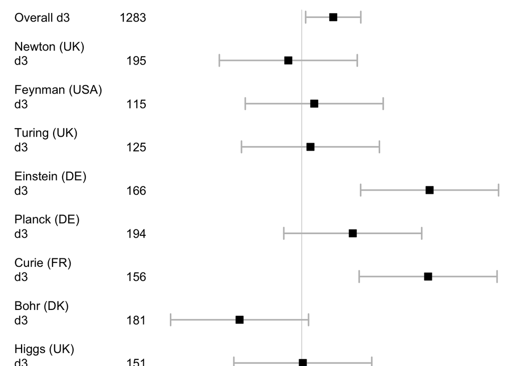

```r
#The forest plot below is only for d3 (rebound effect), as requested by Editor.
library(readxl)
library(forestplot)

data <- read_excel("../../data/processed/RRR_Hyperaccesibility.xlsx", sheet = "forestplotd3") #note new sheet name
View(data)

## The rest of the columns in the table.
tabletext <- cbind(c("Lab (Country)","\n",data$Lab),
                   c("N","\n",data$N)) #\n means new line

forestplot(labeltext=tabletext, graph.pos=3,
           mean=c(NA,NA,data$Point),
           lower=c(NA,NA,data$Low), upper=c(NA,NA,data$High),
           zero=0, cex=0.9, lineheight = unit(5, "mm"), boxsize=0.5, colgap=unit(6,"mm"),
           lwd.ci=2, ci.vertices=TRUE, ci.vertices.height = 0.4)
```

```r
#Updated: Oct 2022 (as requested by Editor)
#Editor requested a meta-analysis of the three-way interaction between Condition, Time Pressure, and Word Type.

#3-way interaction (Condition x Time Pressure x Word Type)
#library(meta)
#summary(intWE92) <- metagen(TE= threeway.beta.int_term, seTE = threeway.SE.int_term, data = RRR_metaWE92)
# summary(intWegner87) <- metagen(TE= threeway.beta.int_term, seTE = threeway.SE.int_term, data = RRR_metaWegner87)
# Ian: no RRR_metaWegner87 exists?
```

some of the code in the previous chunk is commented out as RRR_metaWegner87 object does not exist.

meta analysis code runs but using simulated data from RRR_Hyperaccesibility.xlsx

# For analysis of any single lab, import only one datafile at any one time.

```r
# RRR_WE92 <- read_excel("Arbula_ISSA_Study1_cleaned.xlsx", sheet = "testdata", na = "NA")
# RRR_WE92 <- read_excel("Astle_TAM_Study1_cleaned.xlsx", sheet = "testdata", na = "NA")
# RRR_WE92 <- read_excel("Baldwin_GSU_Study1_cleaned.xlsx", sheet = "testdata", na = "NA")
# RRR_WE92 <- read_excel("Barbu_AICU_Study1_cleaned.xlsx", sheet = "testdata", na = "NA")
# RRR_WE92 <- read_excel("Brady_WFU_Study1_cleaned.xlsx", sheet = "testdata", na = "NA")
# RRR_WE92 <- read_excel("Calvillo_CSU_Study1_cleaned.xlsx", sheet = "testdata", na = "NA")
# RRR_WE92 <- read_excel("Chan_NTU_Study1_cleaned.xlsx", sheet = "testdata", na = "NA")
# RRR_WE92 <- read_excel("Chen_PKU_Study1_cleaned.xlsx", sheet = "testdata", na = "NA")
# RRR_WE92 <- read_excel("Dewitte_KUL_Study1_cleaned.xlsx", sheet = "testdata", na = "NA")
# RRR_WE92 <- read_excel("Fiedler_Bamberg_Study1_cleaned.xlsx", sheet = "testdata", na = "NA")
# RRR_WE92 <- read_excel("Hawk_Digipen_Study1_cleaned.xlsx", sheet = "testdata", na = "NA")
# RRR_WE92 <- read_excel("Heiman_IU_Study1_cleaned.xlsx", sheet = "testdata", na = "NA")
# RRR_WE92 <- read_excel("Hussey_Bern_Study1_cleaned.xlsx", sheet = "testdata", na = "NA")
# RRR_WE92 <- read_excel("Kim_WU_Study1_cleaned.xlsx", sheet = "testdata", na = "NA")
# RRR_WE92 <- read_excel("Ku_SYSU_Study1_cleaned.xlsx", sheet = "testdata", na = "NA")
# RRR_WE92 <- read_excel("Kumalasari_UPI_Study1_cleaned.xlsx", sheet = "testdata", na = "NA")
# RRR_WE92 <- read_excel("Labarta_UCSD_Study1_cleaned.xlsx", sheet = "testdata", na = "NA")
# RRR_WE92 <- read_excel("Légal_UPN_Study1_cleaned.xlsx", sheet = "testdata", na = "NA")
# RRR_WE92 <- read_excel("Liem_Maret _Study1_cleaned.xlsx", sheet = "testdata", na = "NA")
# RRR_WE92 <- read_excel("Lin_USTC_Study1_cleaned.xlsx", sheet = "testdata", na = "NA")
# RRR_WE92 <- read_excel("Linden_CSU_Study1_cleaned.xlsx", sheet = "testdata", na = "NA")
# RRR_WE92 <- read_excel("Lopez_WPI_Study1_cleaned.xlsx", sheet = "testdata", na = "NA")
# RRR_WE92 <- read_excel("Ma-Kellams_SJSU_Study1_cleaned.xlsx", sheet = "testdata", na = "NA")
# RRR_WE92 <- read_excel("Majeed_UCMerced_Study1_cleaned.xlsx", sheet = "testdata", na = "NA")
# RRR_WE92 <- read_excel("Mammarella_UP_Study1_cleaned.xlsx", sheet = "testdata", na = "NA")
# RRR_WE92 <- read_excel("Moskowitz_LU_Study1_cleaned.xlsx", sheet = "testdata", na = "NA")
# RRR_WE92 <- read_excel("Ngyuen_UCSF_Study1_cleaned.xlsx", sheet = "testdata", na = "NA")
# RRR_WE92 <- read_excel("Prada_Lisbon_Study1_cleaned.xlsx", sheet = "testdata", na = "NA")
# RRR_WE92 <- read_excel("Quek_NUS_Study1_cleaned.xlsx", sheet = "testdata", na = "NA")
# RRR_WE92 <- read_excel("Saraiva_ISPA_Study1_cleaned.xlsx", sheet = "testdata", na = "NA")
# RRR_WE92 <- read_excel("Torka_TUD_Study1_cleaned.xlsx", sheet = "testdata", na = "NA")
# RRR_WE92 <- read_excel("Wang_HHU_Study1_cleaned.xlsx", sheet = "testdata", na = "NA")
# RRR_WE92 <- read_excel("Wilkowski_Wyoming_Study1_cleaned.xlsx", sheet = "testdata", na = "NA")
# RRR_WE92 <- read_excel("Wong_UNott_Study1_cleaned.xlsx", sheet = "testdata", na = "NA")
# RRR_WE92 <- read_excel("Xu_SISU_Study1_cleaned.xlsx", sheet = "testdata", na = "NA")
# RRR_WE92 <- read_excel("Yusainy_Brawijaya_Study1_cleaned.xlsx", sheet = "testdata", na = "NA")
```

# Other issues

## All rounding in the code is done via round() which does not round the way people think

`round(3.5)` = 4, but `round(4.5)` also = 4.

all round() should be changed to janitor::round_half_up().

## Double rounding

In study 1, df1 is rounded, then summarized across sites, then rounded again for reporting. Double rounding should be avoided as it distorts estimates.